# papaja

5/3/2021

## Why leave the Word comfort zone…?

### good for science

- transparency
- error prevention (see eg. [“statcheck”](https://link.springer.com/article/10.3758/s13428-015-0664-2))

### good for you

- free + open source
- flexible: easily change from APA to eg. Chicaco Style
- prevent errors (eg. rounding errors, copying the wrong result, correct mistakes, report “what if…” results)
- annotate and motivate your analytic + reporting choices despite space requirements in the final document

## `papaja`: what it does

- Package built and maintained by [Frederik Aust](https://twitter.com/FrederikAust) & Marius Barth, see manual [here](http://frederikaust.com/papaja_man/).
- builds on existing tools for reproducible documents (RMarkdown, pandoc, knitr, …)
- simplifies their use for APA-style reports

  ```
    .wordx          .pdf          .html
  ```

- additional functions that simplify reporting
  - results of common statistical tests
  - APA-style figures
  - APA-style tables
- functions to [cite R packages](http://frederikaust.com/papaja_man/writing.html#citing-r-and-its-packages)
- entry level drug ᕕ( ᐛ )ᕗ

## Set-up

### Needed:

- R + RMarkdown + pandoc
- install `papaja` package and restart RStudio
- LaTeX distribution for creating PDFs

### Recommended:

- latest version RStudio
- reference manager (eg. Zotero)

## Writing in markdown

- separate **text** from **format** from **analysis results**
- **knit** these together to build a document
- added flexibility while preserving transparency & reproducibility

## Error in …

At every stage, things may not work as you think they should work.

Don’t panic.

[Read error logs](http://frederikaust.com/papaja_man/tips-and-tricks.html#troubleshooting), documentations, ask google, ask friends at OSCL, twitter or [StackOverflow](https://stackoverflow.com/questions/tagged/papaja)

## Before we begin…

- global vs. local [chunk options:](https://yihui.org/knitr/options/)
- top to bottom evaluation, caching
- working directory should contain all necessary files:
  - .bib file(s)
  - additional figures used (eg. University logo)
  - data

## Writing in RMarkdown

```
    # Header 1
    ## Header 2

    *italics*
    **bold**

    $ mathematical stuff in LaTeX syntax $

    <!-- comment in markdown -->



    This needs a footnote[^ f1]
    [^ f1]  This is my footnote 1.
```

## Writing in RMarkdown: Code-chunks

### Code chunk:

```{r `HelloWorld`, echo = TRUE}

HW <- paste(“Hello world”)

HW

```

### In-line R code:

` r HW `

### Chunk-labels

- here: `HelloWorld`
- unique: one label per chunk
- no underscores: `Hello_World` will throw errors
- can be cross-referenced!

## Reporting results: the basics

- Store your analysis output as an object, so you can access it’s values and print your specific result
- inspect structure of this object using `str()`
- print only the value you need

```r
lm_out = lm(formula = dist ~ speed, data = cars)
(summary(lm_out)) # probably used this

str(lm_out) # inspect structure of output object

lm_out$coefficients # show only coefficients

# estimate of effect of speed
b_speed <- lm_out$coefficients[2] # show only effect of speed
str(b_speed) # still not just the estimate, let's see...
b_speed_numeric <- as.numeric(b_speed) # too many decimals
round(b_speed_numeric, digits = 2) # yay!
```

## Reporting results:

- `papaja::printnum()`
  - automatically rounds numbers according to APA guidelines
  - function arguments to adjust default reporting style
  - for in-line R code, papaja automatically applies this function to the provided variable!
- `papaja::printp()`
  - for correctly typesetting p-values

  ```r
  lm_out = lm(formula = dist ~ speed, data = cars)    # store output
  str( summary(lm_out) )                              # inspect structure
  b_speed <- summary(lm_out)$coefficients[2, 1]       # 3.932409

  papaja::printnum(b_speed)                           # "3.93"

  p_speed <- summary(lm_out)$coefficients[2, 4]       # [1] 1.489836e-12
  papaja::printp(p_speed)                             # "< .001"
  ```

## APA in-text report

- `papaja::apa_print(lm_out)`
  - prepare common output objects for convenient reporting in APA style

  ```r
  print_lm <- papaja::apa_print(lm_out)       # store output

  str(print_lm)                               # inspect structure

  print_lm$estimate[[2]]
          # [1] "$b = 3.93$, 95\\% CI $[3.10, 4.77]$"

  print_lm$statistic[[2]]
          # [1] "$t(48) = 9.46$, $p < .001$"

  print_lm$full_result[[2]]
          # "$b = 3.93$, 95\\% CI $[3.10, 4.77]$, $t(48) = 9.46$, $p < .001$"
  ```

## APA figures: ggplot2

```r
library(ggplot2)

#  fitted linear regression model

theme_set(theme_apa(box=TRUE))

ggplot( data = cars
        , aes( speed, dist)) +
  geom_point() +
  geom_smooth( method='lm') +
  labs(
    x = "Car speed"
    , y = "Stopping distance"
  )
```

[output not shown]

## APA tables

```r
papaja::apa_table(
    print_lm$table
    , caption = "A full regression table."
    )

# can't demonstrate in slides :)
```

… see [instructions here.](http://frederikaust.com/papaja_man/reporting.html#tables)

## Figures & Tables

- According to APA, figures & tables are **placed at end of document** by default by papaja
  - for PDF documents, you can overwrite this default behavior in YAML header by setting “floatsintext: yes”
- any plot generated by a chunk is **automatically added**
  - papaja automatically creates a files sub-folder and stores each plot as .pdf and .png
  - by default, resolution at 300DPI. Change using [knitr plot chunk options](https://yihui.org/knitr/options/#plots) (`dev` and `dpi`).
- for consistent APA style, set **global style options**.
  - ggplot2: use papaja’s theme template `theme_apa()`
  - base R: specify that knitr should apply global chunk settings (by default, it does not) using `knitr::opts_knit$set(global.par = TRUE)`
- include external images using `knitr::include_graphics("filename.png")`

## Captions

### Figure captions

- use [text references](http://frederikaust.com/papaja_man/tips-and-tricks.html#text-references) for captions
- convenient: paste pre-defined sentences to Figures across multiple similar plots! - figure captions *can* be added using the chunk options, but causes inconveniences further down the road
- long figure captions may *overflow* (= not fit your page) when rendering to pdf. See help [here.](http://frederikaust.com/papaja_man/reporting.html#figure-captions)

### Table captions

- use `papaja::apa_table()`
- there, table captions are defined within the function, not in-text

## Cross-referencing figures and tables:

- refer to 2nd table as *Table 2* throughout text, and automagically call it *Table 3* after inserting another table before!
- each table / figure should be produced in separate chunk with unique chunk-label which must not contain `_`
- see [bookdown documentation](https://bookdown.org/yihui/bookdown/cross-references.html) for `pdf_document2()` and `word_document2()` format
- cross-reference using

  ```
    \@ref(fig:chunk-label)
    \@ref(tab:chunk-label)
  ```

- preceded by space, eg.

  ```
   Figure\ \@ref(fig:chunk-label)
  ```

## Citation references

- citations are automatically re-ordered alphabetically within subgroup
- separate subgroups by prefixes such as “see also, …”

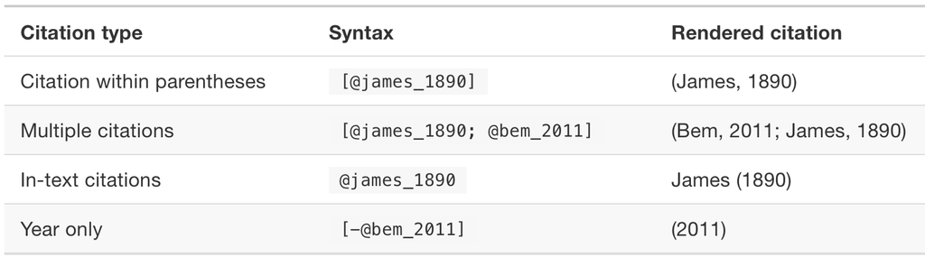

## Building your bibliography

- Many ways to build a .bib file:
  - Rstudio Visual editor: RStudio automatically generates a file called `references.bib`
  - Export a Zotero library under “File -> Export Library… ->” and specify name and directory.
    - Tip: Specify how Zotero should generate Citekeys under Go to Zotero -> Preferences -> Better BibTeX -> Citation Keys, eg. as [authEtAl][year]
  - Create a plain text file in your directory and manually paste citations from journal cites or Google Scholare in BibLaTeX format. Go to Zotero -> Preferences -> Better BibTeX tab.

[figure not shown]

## Rendering / [YAML header](http://frederikaust.com/papaja_man/r-markdown-components.html#yaml-front-matter)

- some info *needs* to be included, eg. author affiliation
- output: `papaja::apa6_pdf`or `papaja::apa6_word`
- classoption “`man"` is APA6 manuscript style,”`doc`" is typical Word doc style
- wordcount: currently only printed to R console, not included in document
- papaja default: `replace_ampersand` for in-text citations for apa citation style, but not when you define different citation style

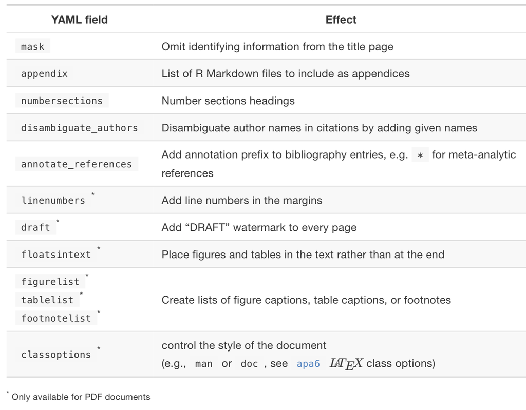

## More resources

- visual editor and menu options in RStudio
- RMarkdown [Cheatsheet](https://www.rstudio.com/wp-content/uploads/2016/03/rmarkdown-cheatsheet-2.0.pdf)
- [R Markdown Cookbook](https://bookdown.org/yihi/rmarkdown-cookbook/)

## Be nice to those who may reproduce:

- don’t include setwd() or install.packages()
- use `here()` package for navigating your directory with relative filepaths
- use devtools::session.info() to report your setup (R version, installed packages etc.)
- go really fancy: preserve your whole computational environment in a container / virtual machine, eg. using docker